## Read Excel Data into an R Data Frame

```r
require("xlsx")
Data_911<-read.xlsx("/home/michael/Downloads/rev data for test.xlsx",1)
```

## 1A) What is the most common reason for calling 911?

```r
table(Data_911$Type)
```

```
##
##         Beaver Accident            Latte Spills Marshawn Lynch Sighting
##                     508                     416                     324
##             Seal Attack
##                     266
```

Beaver Accident appears to be the most common reason for calling 911 with 508 calls, followed by Latte Spills with 416 calls, Lynch Sighting with 324 calls and Seal Attacks with 266 calls.

## 1B) Display these results graphically

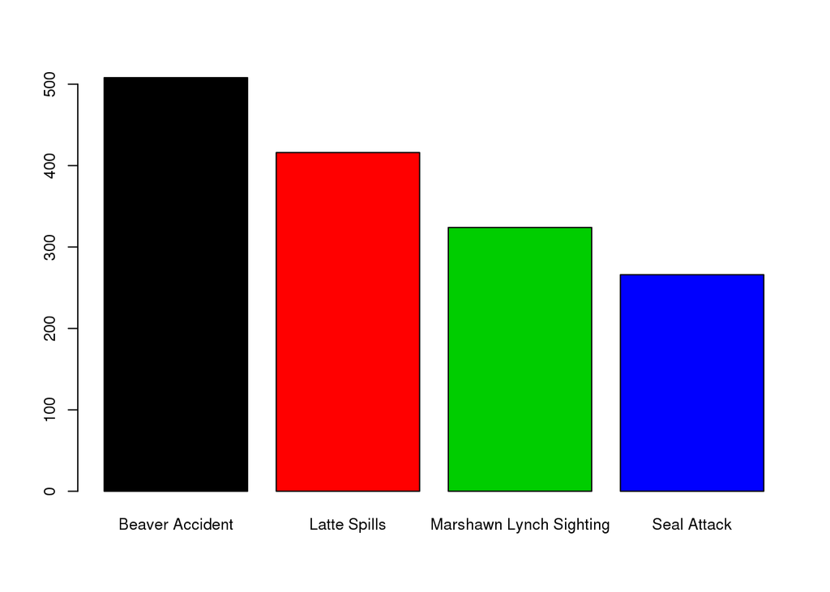

```r
par(cex=0.8)
barplot(table(Data_911$Type),col=c(1:4))
```

## 2A) Please create a graph of the 911 calls using the ‘Latitude’ and ‘Longitude’ (graph type is up to you) (differentiate call type using colors)

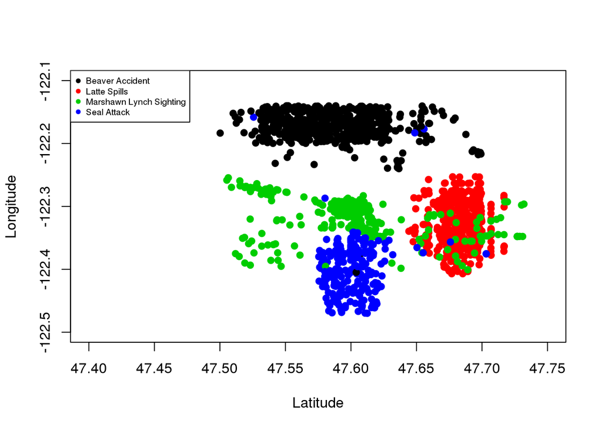

```r
plot(Data_911$Latitude,Data_911$Longitude,col=Data_911$Type,xlab="Latitude",ylab="Longitude",pch=19,xlim=c(47.40,47.75),ylim=c(-122.5,-122.10))
legend(x="topleft",legend=levels(Data_911$Type),col=c(1:4),pch=19,cex=0.6)
```

## 2B) Are there any data points that look mislabeled?

Three of the “Seal Attack” calls appear to be unusually high in Longitude:

```r
Data_911[(Data_911$Type=="Seal Attack" &  Data_911$Longitude > -122.2),]
```

```
##           Type Latitude Longitude                       Report.Location
## 58 Seal Attack 47.65576 -122.1769 (47.5576129536284, -122.176922326574)
## 70 Seal Attack 47.64870 -122.1831 (47.5886759588072, -122.183121688967)
## 81 Seal Attack 47.52570 -122.1581 (47.5756789589651, -122.158119571413)
```

Two of the “Beaver Accident” calls appear to be unusually low in Longitude:

```r
Data_911[(Data_911$Type=="Beaver Accident" &  Data_911$Longitude < -122.3),]
```

```
##                 Type Latitude Longitude
## 1139 Beaver Accident 47.60401 -122.4048
## 1140 Beaver Accident 47.60858 -122.3744
##                            Report.Location
## 1139 (47.6949609996938, -122.280376609491)
## 1140 (47.6748092120779, -122.278621723162)
```

## 2C) If we were to use only ‘Latitude’ and ‘Longitude’ could we make an intelligent decision as to why a resident dialed 911?

If we were willing to tolerate a certain amount of misclassifications due to overlapping decision boundaries, we could find an algorithm that would be correct most of the time.

## 2D) Does the algorithm chosen utilize Euclidean distance? Should we be concerned that ‘Latitude’ and ‘Longitude’ are not necessarily Euclidean?

The algorithm chosen (K-Means Clustering) does use Euclidean distance. For small changes in Latitude and Longitude I think this is a reasonable approximation.

## 2E) Please display the results of your algorithm, along with the associated code

This code fits the K-Means algorithm to the data:

```r
set.seed(42)
Data_911_Cluster <- kmeans(Data_911[,2:3],4)
Data_911_Cluster
```

```
## K-means clustering with 4 clusters of sizes 260, 474, 503, 277
##
## Cluster means:
##   Latitude Longitude
## 1 47.59579 -122.3982
## 2 47.68369 -122.3264
## 3 47.58531 -122.1714
## 4 47.58842 -122.3112
##
## Clustering vector:
##    [1] 2 2 2 2 2 2 3 3 3 3 3 3 3 3 3 3 3 3 3 3 3 3 3 3 3 3 3 3 3 3 3 3 3 3
##   [35] 3 3 3 3 3 3 3 3 3 3 3 3 3 3 3 3 3 3 3 3 3 3 3 3 3 3 3 3 3 3 3 3 3 3
##   [69] 3 3 3 3 3 3 3 3 3 3 3 3 3 3 3 3 3 3 3 3 3 3 3 3 3 3 3 3 3 3 3 3 3 3
##  [103] 3 3 3 3 3 3 3 3 3 3 3 3 3 3 3 3 3 3 3 3 3 3 3 3 3 3 3 3 3 3 3 3 3 3
##  [137] 3 3 3 3 3 3 3 3 3 3 3 3 3 3 3 3 3 3 3 3 3 3 3 3 3 3 3 3 3 3 3 3 3 3
```

[output cut: 50 more lines]

Checking the assigned clusters to the 911 Call Types shows that the clusters do appear to match the call types fairly well (Cluster3 = Beaver Accident, Cluster 4 = Marshawn Lynch Sighting, Cluster 1 = Seal Attack, Cluster2 = Latte Spills)

```r
table(Data_911_Cluster$cluster, Data_911$Type)
```

```
##
##     Beaver Accident Latte Spills Marshawn Lynch Sighting Seal Attack
##   1               2            0                      19         239
##   2               6          416                      47           5
##   3             500            0                       0           3
##   4               0            0                     258          19
```